# **Analisi delle Componenti Principali**

# Dati Marks

1. Caricare i dati `marks`

```r
marks <- read.table("http://www.maths.leeds.ac.uk/~charles/mva-data/openclosedbook.dat",header = TRUE)
X = as.matrix(marks)
# assegno i nomi alle variabili
colnames(X) <- c("Mechanics", "Vectors", "Algebra", "Analysis", "Statistics")
# guardo le prime righe
head(X)
```

```
     Mechanics Vectors Algebra Analysis Statistics
[1,]        77      82      67       67         81
[2,]        63      78      80       70         81
[3,]        75      73      71       66         81
[4,]        55      72      63       70         68
[5,]        63      63      65       70         63
[6,]        53      61      72       64         73
```

```r
n = nrow(X)
p = ncol(X)
```

2. Calcolare la matrice dei dati centrati $\tilde{X}$ come trasformazione lineare $\underset{n\times p}{X}\underset{p\times q}{A'} + \underset{n\times 1}{1}\underset{1\times q}{b'}$ con $q=p$, $A = \underset{p\times p}{I}$ e $b = -\underset{p\times 1}{\bar{x}}$

```r
A = diag(rep(1,p))
one.n = matrix(rep(1,n))
b = (1/n) * t(X) %*% one.n

Xtilde = X %*% t(A) + one.n %*% (-t(b))
```

2. Calcolare il voto medio di ciascun studente come combinazione lineare $\underset{n\times 1}{y} = \underset{n\times p}{X}\underset{p\times 1}{a}$ con $a_j = 1/p$, $j=1,\ldots,p$

```r
a = matrix(rep(1/p, p), ncol=1)
y = X %*% a
```

2. Calcolare la prima componente principale di $\tilde{X}$ come $\underset{n\times 1}{y_1} = \underset{n\times p}{\tilde{X}} \underset{p\times 1}{v_1}$ dove $v_1$ è il primo autovettore di $S=\frac{1}{n} \tilde{X}' \tilde{X}$ associato all’autovalore più grande $\lambda_1$. Verificare che la varianza di $y_1$ è pari a $\lambda_1$ e che è maggiore della varianza della combinazione lineare normalizzata $\underset{n\times 1}{y} = \underset{n\times p}{\tilde{X}}\underset{p\times 1}{a}$ con $a_j = 1/\sqrt{p}$, $j=1,\ldots,p$.

```r
# decomposizione spettrale di S
S = (1/n) * t(Xtilde) %*% Xtilde
eigen = eigen(S)
Lambda = diag(eigen$values)
V = eigen$vectors

# pesi (loadings) della 1ma componente principale
v1 = V[,1, drop=FALSE]
v1
```

```
           [,1]
[1,] -0.5054457
[2,] -0.3683486
[3,] -0.3456612
[4,] -0.4511226
[5,] -0.5346501
```

```r
# punteggi (scores) della 1ma componente principale
y1 = Xtilde %*% v1

# varianza di y1
var(y1) * (n-1)/n # coincide con Lambda[1,1]
```

```
         [,1]
[1,] 679.1831
```

```r
# confronto con altra combinazione lineare normalizzata
a = matrix(rep(1/sqrt(p), p), ncol=1)
y = Xtilde %*% a
var(y) * (n-1)/n
```

```
         [,1]
[1,] 662.6463
```

3. Calcolare le $p$ componenti principali $\underset{n\times p}{Y} = \underset{n\times p}{\tilde{X}} \underset{p\times p}{V}$. Verificare che il vettore medio di $Y$ è nullo, la matrice di varianze/covarianze $S^Y$ di $Y$ è pari a $\Lambda$, che la varianza totale e generalizzata di $S^Y$ è pari a quella di $S$

```r
# p componenti principali Y
Y = Xtilde %*% V

# vettore medio di Y
round(
(1/n) * t(Y) %*% one.n
, 8)
```

```
     [,1]
[1,]    0
[2,]    0
[3,]    0
[4,]    0
[5,]    0
```

```r
# matrice di varianze covarianze di Y
S_Y = (1/n) * t(Y) %*% Y # coincide con Lambda
round(
S_Y
, 8)
```

```
         [,1]     [,2]     [,3]     [,4]     [,5]
[1,] 679.1831   0.0000   0.0000  0.00000  0.00000
[2,]   0.0000 199.8144   0.0000  0.00000  0.00000
[3,]   0.0000   0.0000 102.5684  0.00000  0.00000
[4,]   0.0000   0.0000   0.0000 83.66873  0.00000
[5,]   0.0000   0.0000   0.0000  0.00000 31.78791
```

```r
# varianza totale di S_Y
sum(diag(S_Y)) # coincide con sum(diag(S_Y))
```

```
[1] 1097.022
```

```r
# varianza generalizzata di S_Y
det(S_Y) # coincide con det(S)
```

```
[1] 37021339491
```

4. Calcolare le componenti principali con il comando `princomp()` e `prcomp()`

```r
pca = princomp(X)
summary(pca) # Standard deviation coincide con sqrt(diag(Lambda))
```

```
Importance of components:
                          Comp.1     Comp.2      Comp.3     Comp.4     Comp.5
Standard deviation     26.061142 14.1355705 10.12760414 9.14706148 5.63807655
Proportion of Variance  0.619115  0.1821424  0.09349705 0.07626893 0.02897653
Cumulative Proportion   0.619115  0.8012575  0.89475453 0.97102347 1.00000000
```

```r
# pesi
pca$loadings[,] # coincide con V
```

```
              Comp.1      Comp.2     Comp.3       Comp.4      Comp.5
Mechanics  0.5054457  0.74874751  0.2997888  0.296184264  0.07939388
Vectors    0.3683486  0.20740314 -0.4155900 -0.782888173  0.18887639
Algebra    0.3456612 -0.07590813 -0.1453182 -0.003236339 -0.92392015
Analysis   0.4511226 -0.30088849 -0.5966265  0.518139724  0.28552169
Statistics 0.5346501 -0.54778205  0.6002758 -0.175732020  0.15123239
```

```r
# punteggi
head( pca$scores ) # coincide con head(Y)
```

```
       Comp.1     Comp.2     Comp.3     Comp.4     Comp.5
[1,] 66.32077   6.447125  7.0736275 -9.6463833  5.4557651
[2,] 63.61810  -6.754424  0.8599283 -9.1490636 -7.5656517
[3,] 62.92626   3.080258 10.2297139 -3.7238434 -0.3841125
[4,] 44.53775  -5.577218 -4.3780192 -4.4816746  4.4065605
[5,] 43.28425   1.133228 -1.5314139  5.8059805  0.7378218
[6,] 42.55249 -10.972900  4.8671678 -0.4788987 -7.1021171
```

```r
pca2 = prcomp(X, center = TRUE)
summary(pca2)  # Standard deviation coincide con sqrt(diag(Lambda)*(n/n-1))
```

```
Importance of components:
                           PC1     PC2     PC3     PC4     PC5
Standard deviation     26.2105 14.2166 10.1856 9.19948 5.67039
Proportion of Variance  0.6191  0.1821  0.0935 0.07627 0.02898
Cumulative Proportion   0.6191  0.8013  0.8948 0.97102 1.00000
```

```r
# pesi
pca2$rotation[,] # coincide con V
```

```
                  PC1         PC2        PC3          PC4         PC5
Mechanics  -0.5054457 -0.74874751  0.2997888 -0.296184264 -0.07939388
Vectors    -0.3683486 -0.20740314 -0.4155900  0.782888173 -0.18887639
Algebra    -0.3456612  0.07590813 -0.1453182  0.003236339  0.92392015
Analysis   -0.4511226  0.30088849 -0.5966265 -0.518139724 -0.28552169
Statistics -0.5346501  0.54778205  0.6002758  0.175732020 -0.15123239
```

```r
# punteggi
head( pca2$x ) # coincide con head(Y)
```

```
           PC1       PC2        PC3        PC4        PC5
[1,] -66.32077 -6.447125  7.0736275  9.6463833 -5.4557651
[2,] -63.61810  6.754424  0.8599283  9.1490636  7.5656517
[3,] -62.92626 -3.080258 10.2297139  3.7238434  0.3841125
[4,] -44.53775  5.577218 -4.3780192  4.4816746 -4.4065605
[5,] -43.28425 -1.133228 -1.5314139 -5.8059805 -0.7378218
[6,] -42.55249 10.972900  4.8671678  0.4788987  7.1021171
```

5. Calcolare la correlazione tra il voto centrato sullo 0 dell’esame in `Statistics` (quinta colonna della matrice $\tilde{X}$) e i punteggi della prima componente principale (prima colonna della matrice $Y$). Si ricordi la formula
   $$\frac{v_{jk}\sqrt{\lambda_k}}{\sqrt{s_{jj}}}$$
   per la $j$-sima colonna di $\tilde{X}$ e la $k$-sima colonna di $Y$.

```r
V[5,1]*pca$sdev[1]/sqrt(diag(S)[5])
```

```
    Comp.1
-0.8121103
```

```r
# corrisponde alla correlazione calcolata sulla base dei dati
cor(Xtilde[,"Statistics"],Y[,1])
```

```
[1] -0.8121103
```

6. Scegliere il numero $q$ di componenti principali utilizzando i criteri (i) proporzione di varianza spiegata dalle prime $q$ componenti superiore all’80%; (ii) varianza spiegata da ciascuna componente maggiore di $c=\frac{1}{p}\sum_{j=1}^{p}\lambda_j$ (iii) utilizzando lo *scree plot*.

```r
# scelta di q: proporzione di varianza spiegata > 80%
summary(pca)
```

```
Importance of components:
                          Comp.1     Comp.2      Comp.3     Comp.4     Comp.5
Standard deviation     26.061142 14.1355705 10.12760414 9.14706148 5.63807655
Proportion of Variance  0.619115  0.1821424  0.09349705 0.07626893 0.02897653
Cumulative Proportion   0.619115  0.8012575  0.89475453 0.97102347 1.00000000
```

```r
# scelta di q: varianza spiegata > c
c = mean(pca$sdev^2)
pca$sdev^2 > c
```

```
Comp.1 Comp.2 Comp.3 Comp.4 Comp.5
  TRUE  FALSE  FALSE  FALSE  FALSE
```

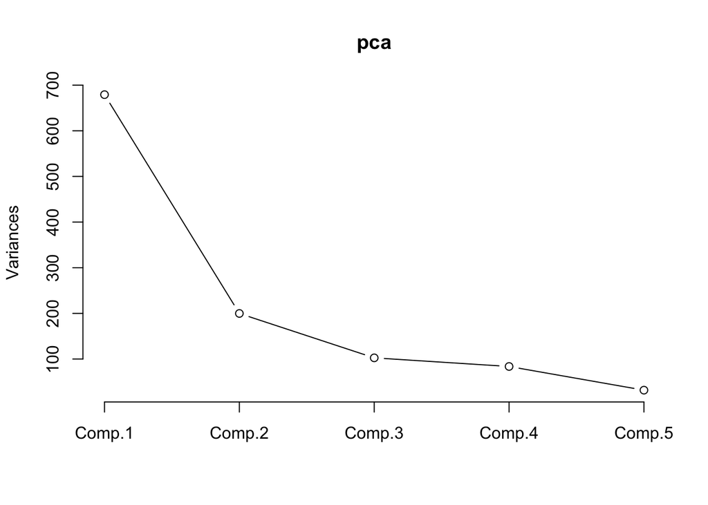

```r
# scelta di q: scree plot
plot(pca, type="line")
```

# Biplot

Con i dati utilizzati nell’esempio precedente, costruire il *biplot* con il comando `biplot()`.

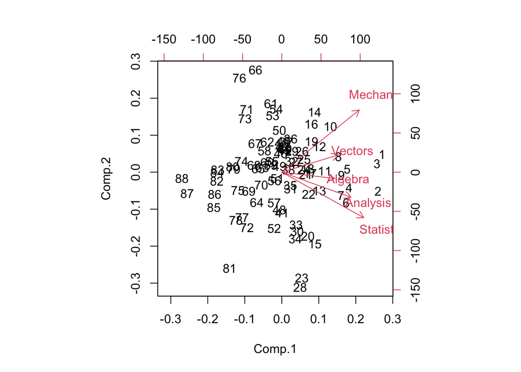

```r
# biplot
biplot(pca)
```

La funzione `biplot()` rappresenta

1. gli AUTOVETTORI NON STANDARDIZZATI = AUTOVETTORI * SQRT(AUTOVALORI), moltiplicati poi per un fattore 0.8 * sqrt(n-1)
2. i PUNTEGGI RISCALATI (in modo che la somma dei valori al quadrato sia pari a 1)

In R:

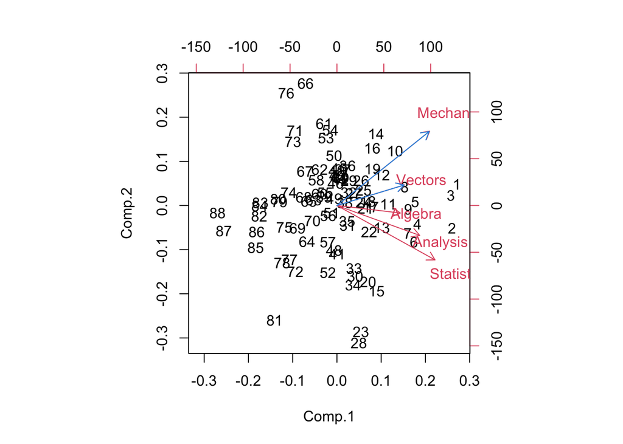

```r
# AUTOVETTORI (PESI)
V = eigen(S)$vectors
V[,1] = -V[,1]

# AUTOVALORI (VARIANZE)
lambda = eigen(S)$values

# AUTOVETTORI NON STANDARDIZZATI
VL = V %*% diag(sqrt(lambda))

# PUNTEGGI
Y = Xtilde %*% V

# BIPLOT
PCA = princomp(Xtilde)
biplot(PCA)
# sovrascrivo le frecce in blu per le prime due variabili
arrows(0, 0,
VL[1,1] * 0.8 * sqrt(n - 1),
VL[1,2] * 0.8 * sqrt(n - 1),
lwd = 1, angle = 30, length = 0.1, col = 4)
arrows(0, 0,
VL[2,1] * 0.8 * sqrt(n - 1),
VL[2,2] * 0.8 * sqrt(n - 1),
lwd = 1, angle = 30, length = 0.1, col = 4)
```

```r
# PUNTEGGI RISCALATI (la somma dei valori al quadrato di ciascuna colonna è 1)
Ystd = Y %*% diag(1/(sqrt(lambda)*sqrt(n)))
colSums(Ystd^2)
```

```
[1] 1 1 1 1 1
```

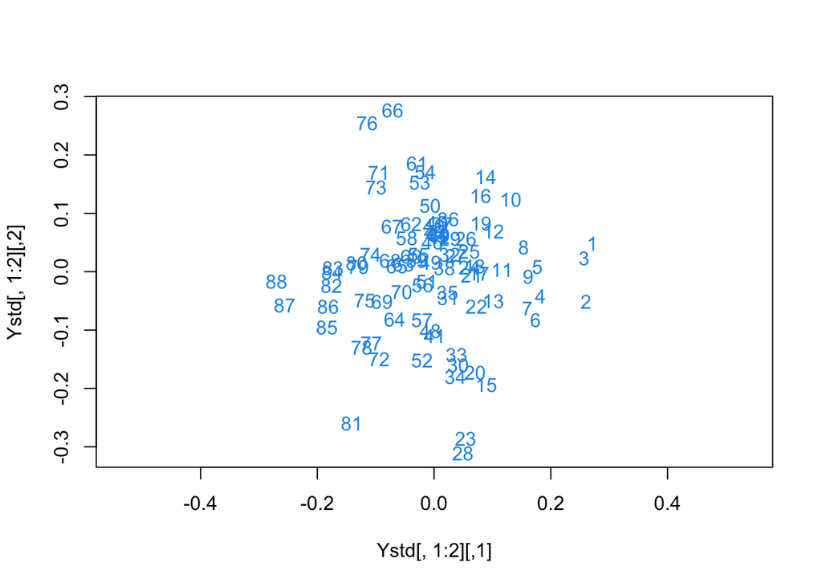

```r
labs = as.character(1:n)
plot(Ystd[,1:2], asp=1, type = "n")
text(Ystd[,1:2], labs, col=4)
```

# Dati Wine

```r
rm(list=ls())
wine <- read.csv("https://archive.ics.uci.edu/ml/machine-learning-databases/wine/wine.data", header  = FALSE)
colnames(wine)<-c("Type","Alcohol",
                  "Malic","Ash",
                  "Alcalinity","Magnesium",
                  "Phenols","Flavanoids",
                  "Nonflavanoids","Proanthocyanins",
                  "Color_int","Hue","Dilution","Proline")
wine$Type = factor(wine$Type)
X = as.matrix(wine[,-1])
n = nrow(X)
p = ncol(X)

# PCA
pca = princomp(X, cor=T)

V = pca$loadings
Y = pca$scores

# prop. di varianza spiegata dalle prime q cp
q <- 10
cumsum(pca$sdev^2/sum(pca$sdev^2))[1:q]
```

```
   Comp.1    Comp.2    Comp.3    Comp.4    Comp.5    Comp.6    Comp.7    Comp.8    Comp.9   Comp.10
0.3619885 0.5540634 0.6652997 0.7359900 0.8016229 0.8509812 0.8933680 0.9201754 0.9423970 0.9616972
```

2. Costruire il diagramma di dispersione dei punteggi delle prime due componenti principali, colorando i punti con colori diversi a seconda della tipologia di vino (variabile `type`).

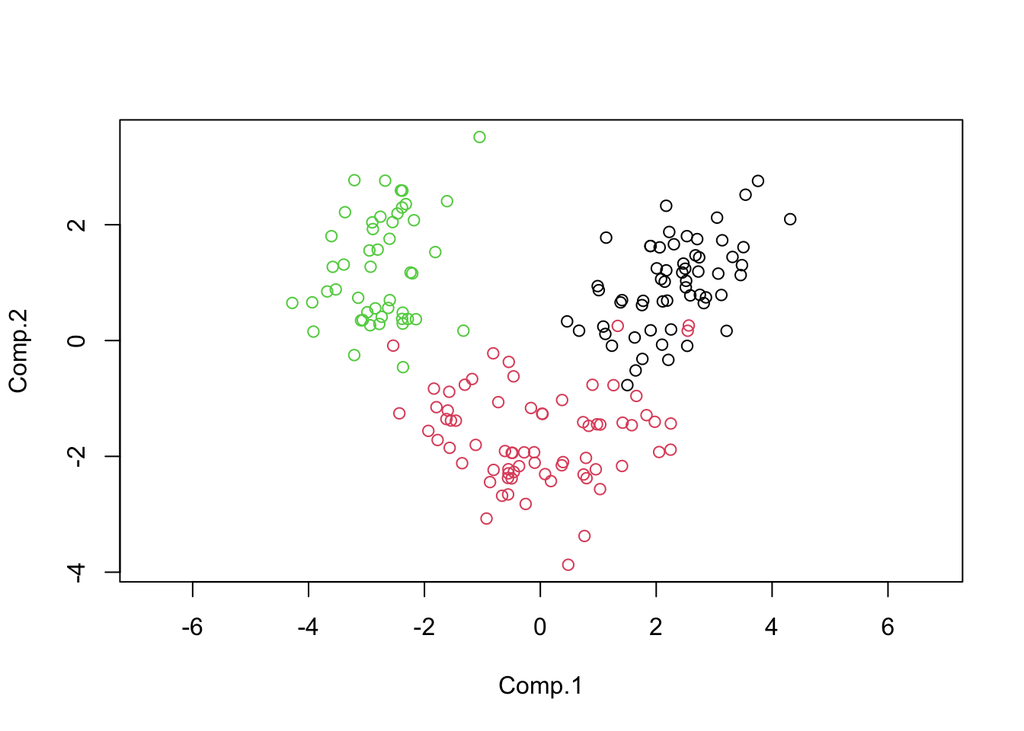

```r
plot(Y[,1:2], col=as.numeric(wine$Type), asp=1)
```

3. Costruire il biplot con la funzione `autoplot` della libreria `ggfortify`.

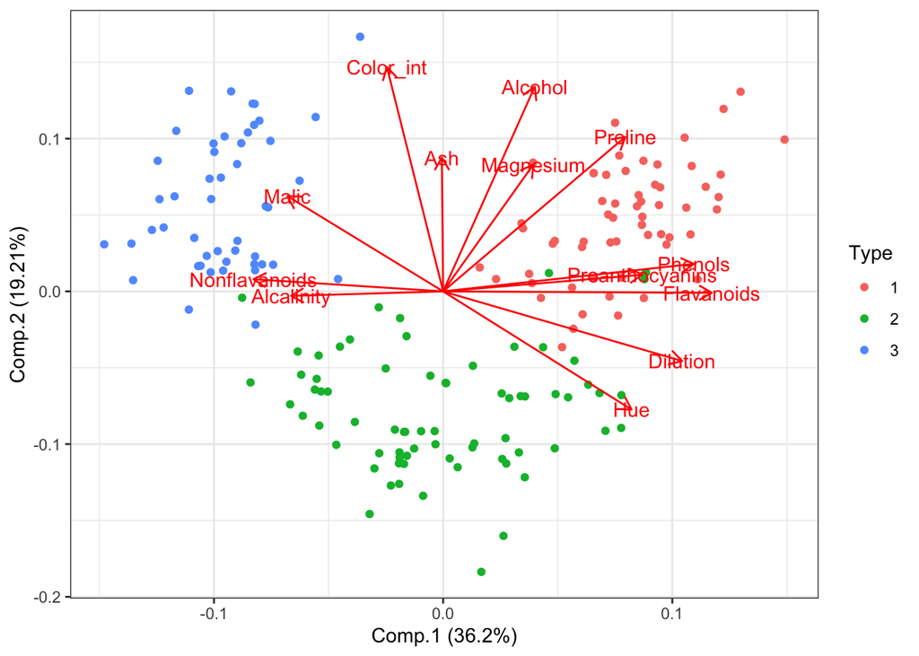

```r
library(ggfortify)
autoplot(pca, data = wine, colour = "Type",
         loadings=TRUE, loadings.label = TRUE) + theme_bw()
```

# Dati Face

1. Importare i dati e visualizzare l’immagine con il comando `image`. Effettuare l’analisi delle componenti principali dei dati centrati $\underset{n\times p}{\tilde{X}}$, calcolando la matrice dei punteggi $\underset{n\times p}{Y} = \underset{n\times p}{\tilde{X}}\underset{p\times p}{V}$ e la matrice dei pesi $\underset{p\times p}{V}$.

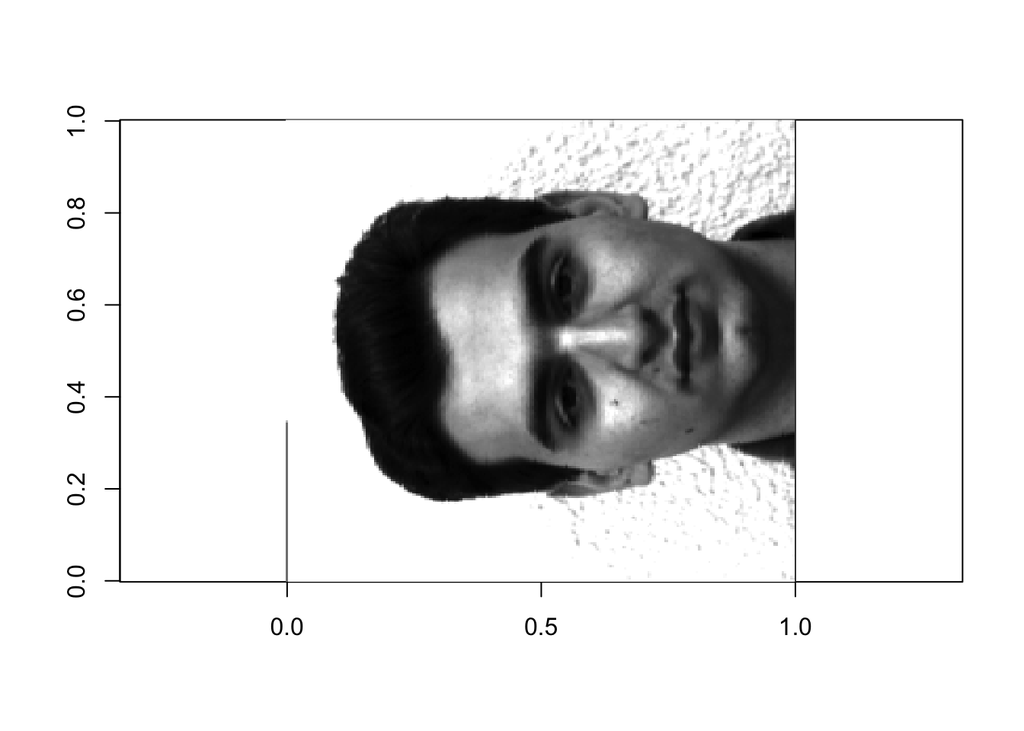

```r
rm(list=ls())
face <- read.table("https://raw.githubusercontent.com/aldosolari/AE/master/docs/dati/face.txt", header=FALSE)

X = as.matrix(face)
n = nrow(face)
p = ncol(face)

# visualizza immagine
image(X, col=gray(0:255/255), asp=p/n)
```

```r
# PCA
pca = princomp(X, cor=F)
V = pca$loadings
Y = pca$scores
xbar = matrix(pca$center, ncol=1)
```

2. Ottenere la migliore approssimazione per $\underset{n\times p}{\tilde{X}}$ di rango $q$, $\underset{n\times p}{A_q} = \underset{n\times q}{Y_q} \underset{q\times p}{V_q'}$, con $q=10$. Costruire l’immagine compressa $\underset{n\times p}{C} = \underset{n\times p}{A_q} + \underset{n\times 1}{1}\underset{1\times p}{\bar{x}}$, assicurandosi che tutti gli elementi di $\underset{n\times p}{C}$ siano compresi tra 0 e 1.

```r
q = 10
Yq = Y[,1:q]
Vq = V[,1:q]

# migliore approssimazione di rango q
Aq = Yq %*% t(Vq)

# compressione immagine
one.n = matrix(rep(1,n), ncol=1)
face2 = Aq + one.n %*% t(xbar)

# forzo i valori tra 0 e 1
face2 <- pmax(pmin(face2, 1), 0)
```

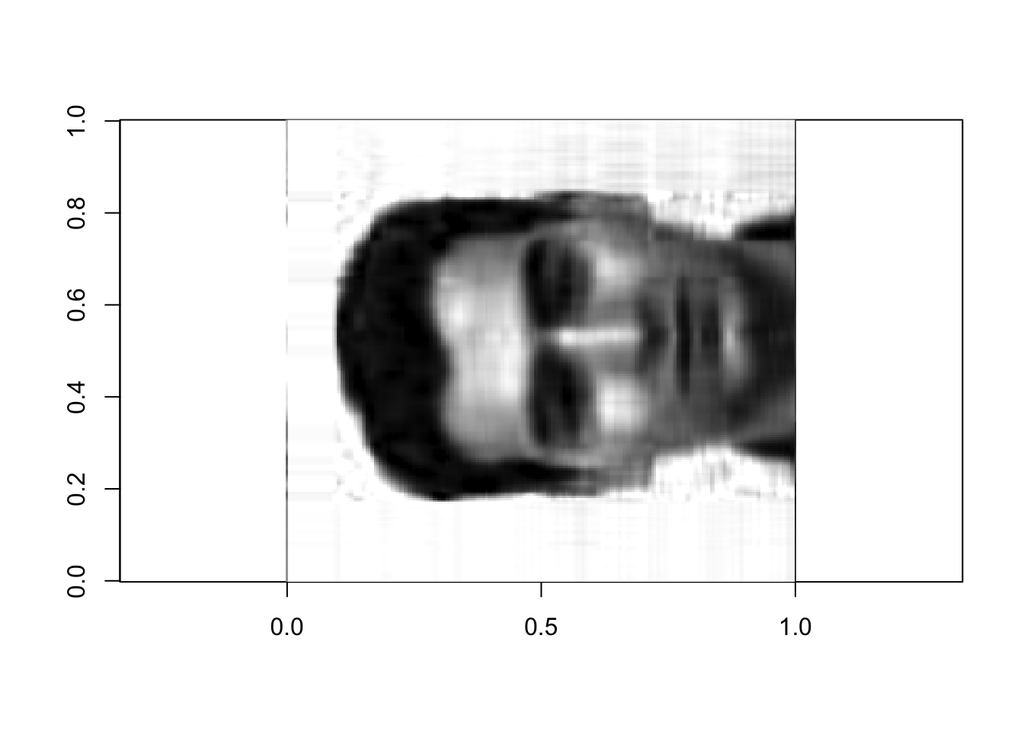

```r
# visualizza immagine compressa
image(face2, col=gray(0:255/255), asp=p/n)
```

```r
# salve immagine compressa
# library(png)
# writePNG(face,"face.png")

# confronta pixels utilizzati

pixels = prod(dim(face))
pixels2 = prod(dim(Yq)) + prod(dim(Vq)) + prod(dim(xbar))
round(pixels/pixels2, 2) # fattore di riduzione
```

```
[1] 11.02
```